# Linear & Non-Linear Models (31010) Week 3 Workshop: Correlation and Dependence

© Yuri Balasanov, iLykei 2016

# 1 Misleading Correlation: Examples

## 1.1 Example of uncorrelated, but dependent variables

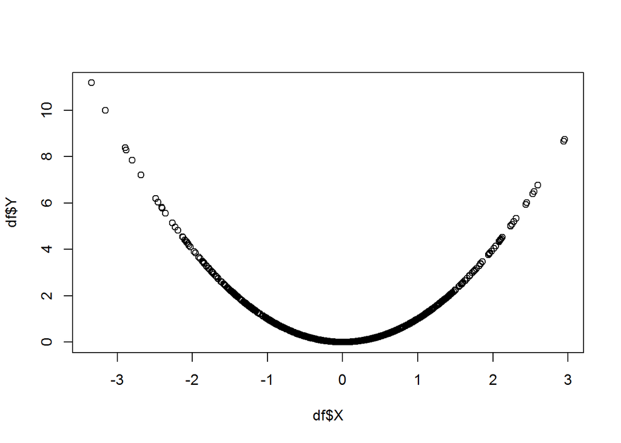

```r
nSample<-1000
set.seed(893075)
Variable.X<-rnorm(nSample,0,1)
Variable.Y<-Variable.X^2
df<-data.frame(X=Variable.X,Y=Variable.Y)
plot(df$X,df$Y)
```

```r
(rho<-cor(Variable.X,Variable.Y))
```

```
## [1] -0.06534263
```

```r
rho^2
```

```
## [1] 0.00426966
```

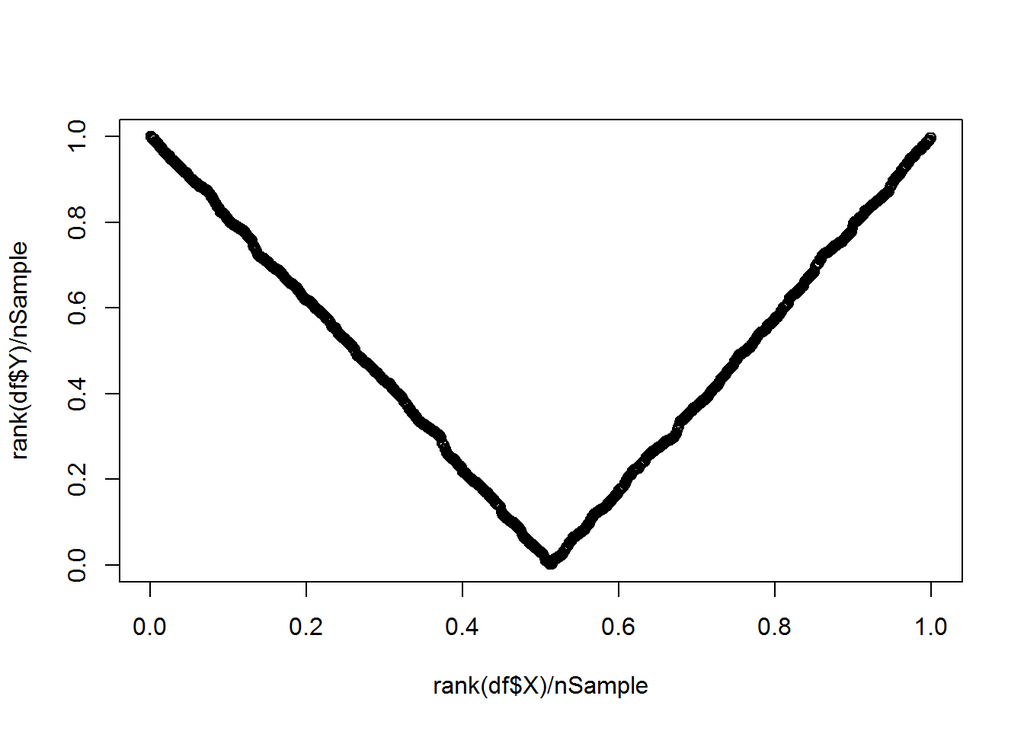

```r
plot(rank(df$X)/nSample,rank(df$Y)/nSample)
```

**Summary:**  
* Variables are dependent  
* Correlation shows no dependence  
* Empirical copula shows strong dependence: countermonotonic in the first part, comonotonic in the second part

## 1.2 The pattern may be explained by marginal distributions rather than dependence between the variables

```r
library(MASS)
set.seed(893075)
Variable.X<-rexp(nSample,1)
Variable.Y<-rnorm(nSample,1,1)
Variable.Z<-rexp(nSample,.3)
df<-data.frame(X=Variable.X,Y=Variable.Y,Z=Variable.Z)
```

Both scatter plots below are for 2 pairs of independent variables.

In one case one marginal distribution is normal, the other is exponential:

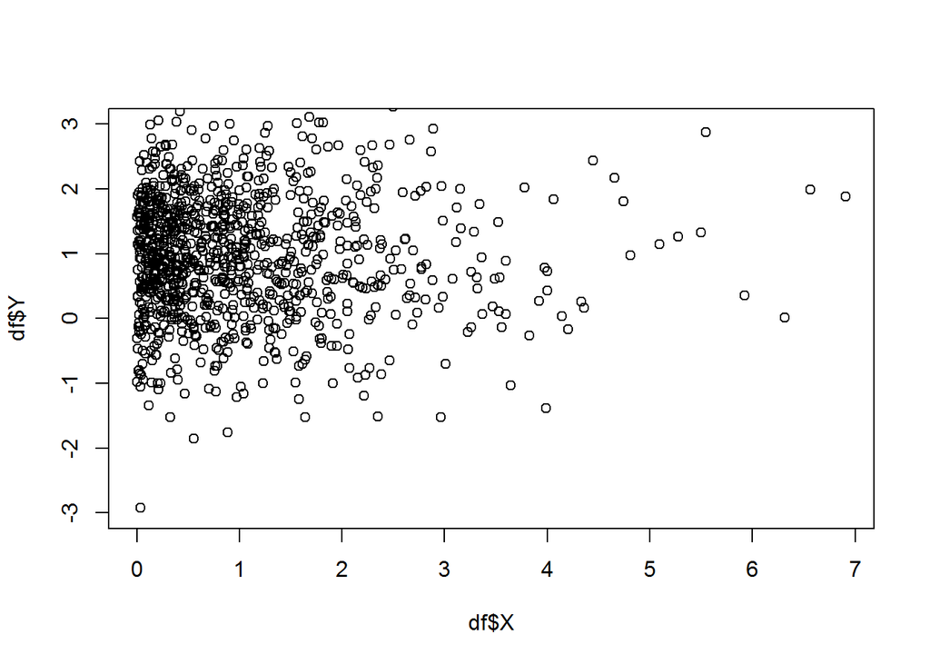

```r
plot(df$X,df$Y,ylim=c(-3,3))
```

```r
cor(df$X,df$Y)
```

```
## [1] -0.02319913
```

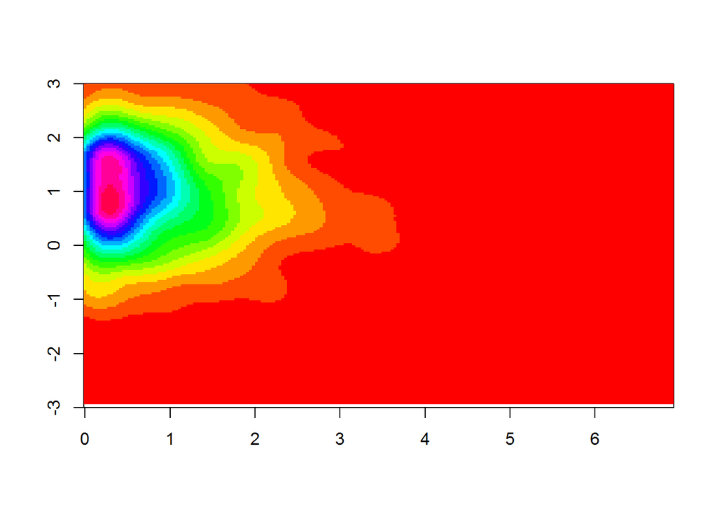

```r
k <- kde2d(df$X, df$Y, n=200)
image(k,col=rainbow(20),ylim=c(-3,3))
```

In another one both of them are exponential:

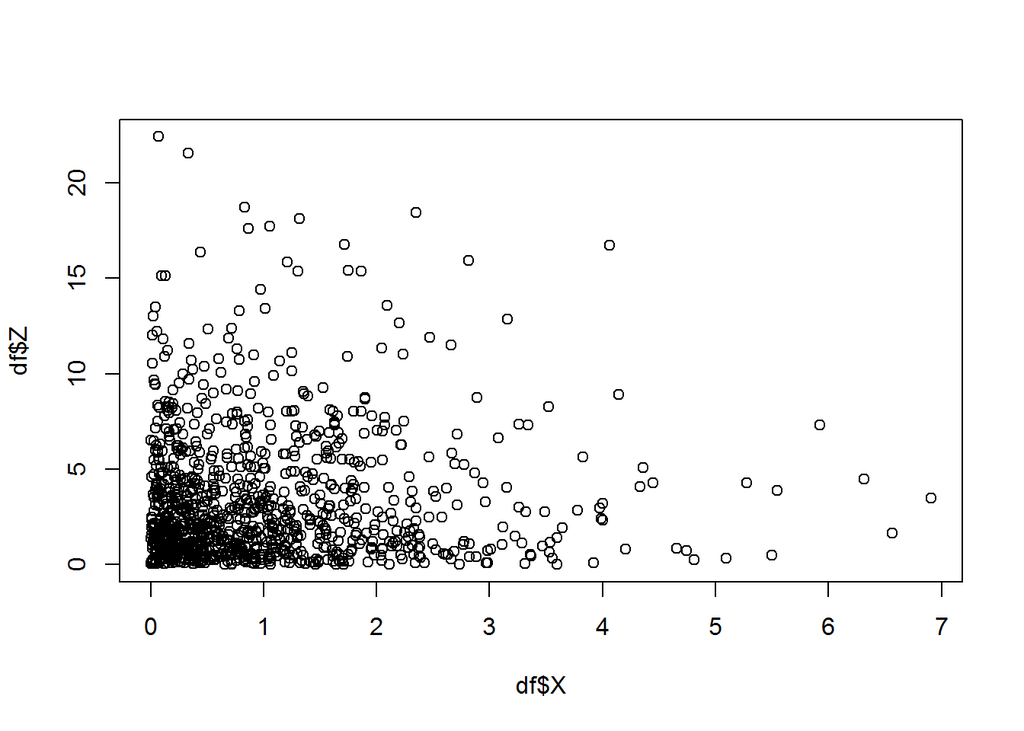

```r
plot(df$X,df$Z)
```

```r
cor(df$X,df$Z)
```

```
## [1] 0.02210377
```

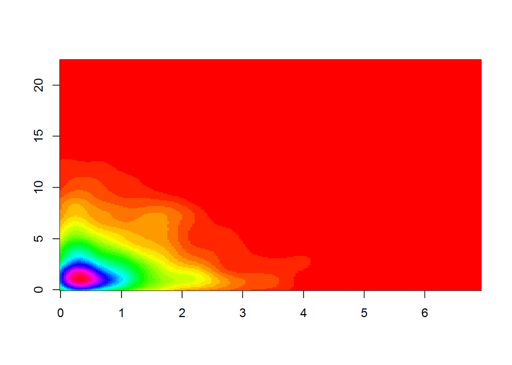

```r
k <- kde2d(df$X, df$Z, n=200)
image(k,col=rainbow(40))
```

Empirical copula shows independence in both cases.

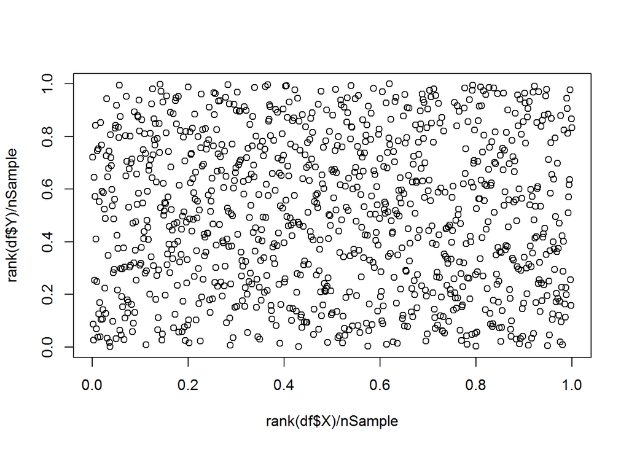

```r
plot(rank(df$X)/nSample,rank(df$Y)/nSample)
```

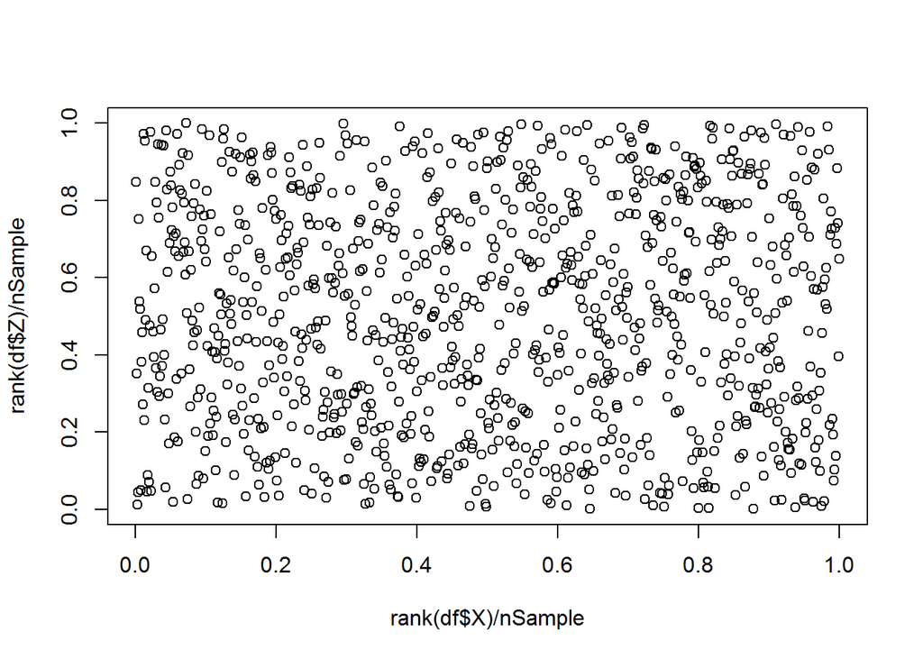

```r
plot(rank(df$X)/nSample,rank(df$Z)/nSample)
```

**Summary:**  
* All 3 variables are independent, but show different patterns  
* Pairwise correlations are not significant  
* Empirical copula shows the independence in both cases

## 1.3 Example of two independent standard normal samples shown on slide 14 in lecture notes

```r
Learning.Sample.X<-c(-2.224,-1.538,-0.807,0.024,0.052,1.324)
Learning.Sample.Y<-c(0.431,1.035,0.586,1.465,1.115,-0.847)
learning.df<-data.frame(X=Learning.Sample.X,Y=Learning.Sample.Y)
cor(learning.df$X,learning.df$Y)^2
```

```
## [1] 0.1577333
```

```r
cor(exp(learning.df$X),3*exp(learning.df$Y))^2
```

```
## [1] 0.2394024
```

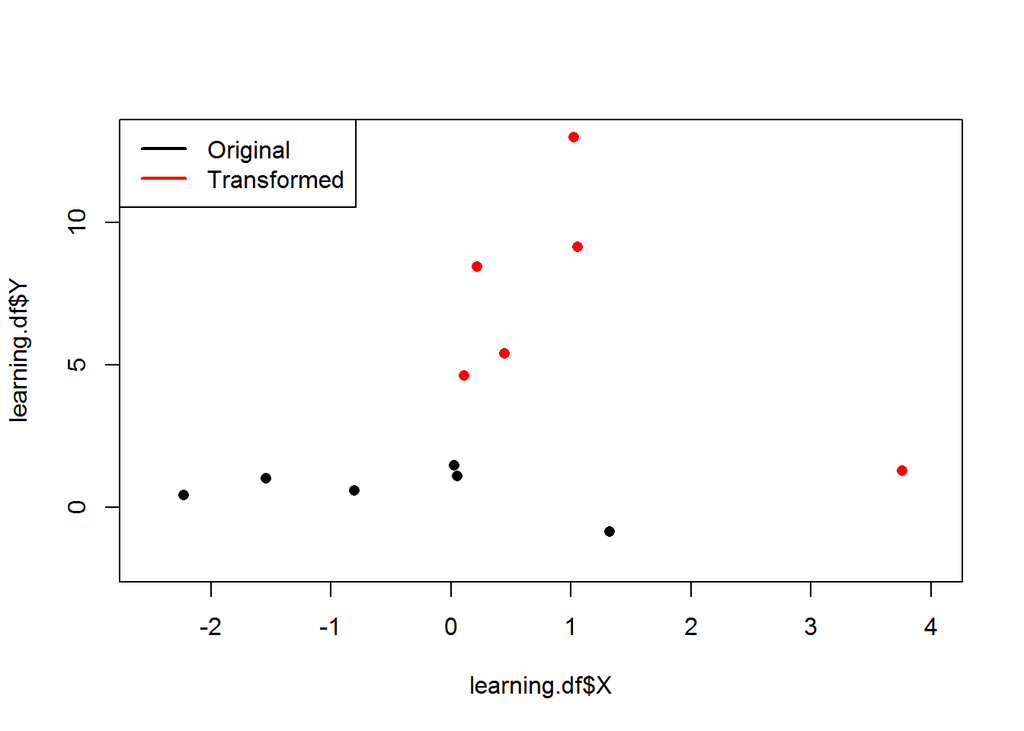

```r
plot(learning.df$X,learning.df$Y,xlim=c(-2.5,4),ylim=c(-2,13),col="black",pch=16)
points(exp(learning.df$X),3*exp(learning.df$Y),col="red",pch=16)
legend("topleft",legend=c("Original","Transformed"),lty=1,lwd=2,col=c("black","red"))
```

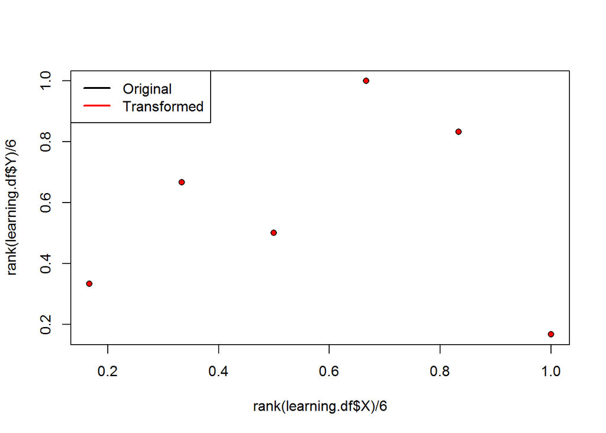

```r
plot(rank(learning.df$X)/6,rank(learning.df$Y)/6,col="black",pch=16)
points(rank(exp(learning.df$X))/6,rank(3*exp(learning.df$Y))/6,col="red",pch=20)
legend("topleft",legend=c("Original","Transformed"),lty=1,lwd=2,col=c("black","red"))
```

**Summary:**  
* The samples are independent regardless of monotonic tranformation  
* Their scatter plot changes after a monotonic transformation  
* Their determination coefficient changes after a monotonic transformation * Their empirical copula remains the same

# 2 Parametric Copulas

Empirical copula is a non-parametric type of copula which is useful as a first step of analysis when we try to evaluate existance and possible type of non-linear dependence.  
Parametric copula models can be fit to the data and used for comparison, simulation, risk analysis and other applications.

## 2.1 Gaussian Copula

```r
library(copula)
```

Correlation for Gaussian copula is the measure of dependence.

### 2.1.1 Case: $\rho=0.9$

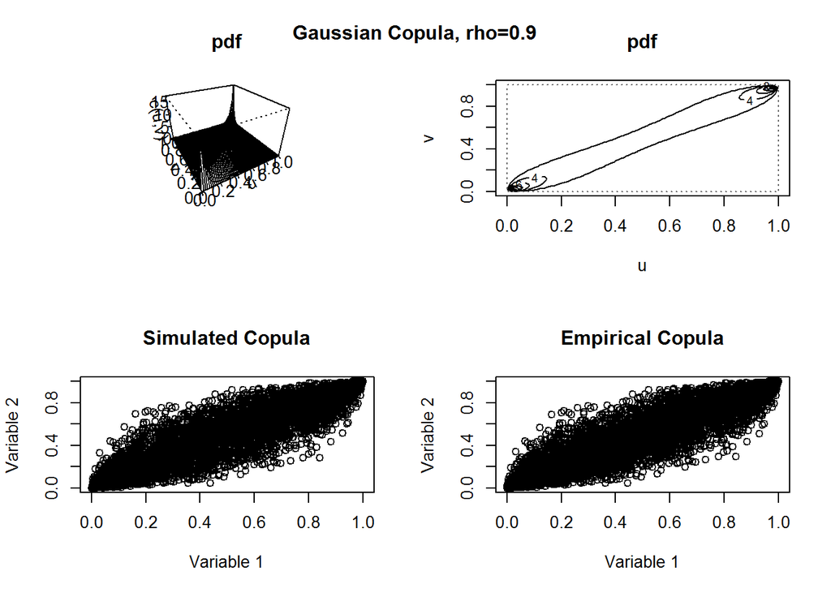

```r
par(mfrow=c(2,2))
set.seed(8301735)
#Gaussian Copula, rho=0.9
Gaussian.Copula.0.9<-normalCopula(param=.9,dim=2)
persp(Gaussian.Copula.0.9, dCopula, main="pdf",xlab="u", ylab="v", zlab="c(u,v)")
contour(Gaussian.Copula.0.9,dCopula, main="pdf",xlab="u", ylab="v")
Simulated.Gaussian.Copula.0.9<-rCopula(5000,Gaussian.Copula.0.9)
SimulatedN<-length(Simulated.Gaussian.Copula.0.9[,1])
plot(Simulated.Gaussian.Copula.0.9,main="Simulated Copula",xlab="Variable 1",ylab="Variable 2")
plot(apply(Simulated.Gaussian.Copula.0.9,2,rank)/SimulatedN,
     main="Empirical Copula",xlab="Variable 1",ylab="Variable 2")
title(main="Gaussian Copula, rho=0.9",outer=TRUE,line=-2)
```

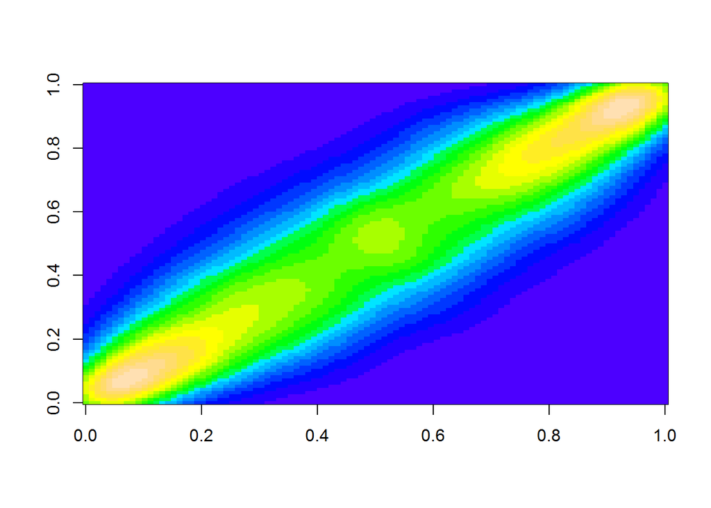

```r
par(mfrow=c(1,1))
k <- kde2d(rank(Simulated.Gaussian.Copula.0.9[,1])/SimulatedN,
           rank(Simulated.Gaussian.Copula.0.9[,2])/SimulatedN, n=100)
image(k,col=topo.colors(20))
```

### 2.1.2 Case: $\rho=-0.9$

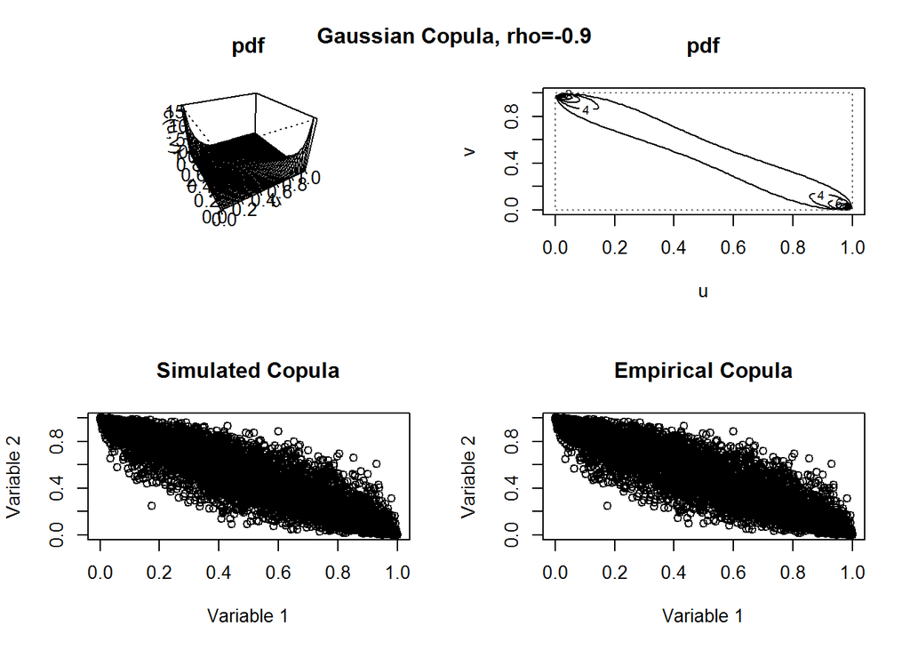

```r
par(mfrow=c(2,2))
set.seed(8301735)
#Gaussian Copula, rho=-0.9
Gaussian.Copula.Minus0.9<-normalCopula(param=-.9,dim=2)
persp(Gaussian.Copula.Minus0.9, dCopula, main="pdf",xlab="u", ylab="v", zlab="c(u,v)")
contour(Gaussian.Copula.Minus0.9,dCopula, main="pdf",xlab="u", ylab="v")
Simulated.Gaussian.Copula.Minus0.9<-rCopula(5000,Gaussian.Copula.Minus0.9)
SimulatedN<-length(Simulated.Gaussian.Copula.Minus0.9[,1])
plot(Simulated.Gaussian.Copula.Minus0.9,main="Simulated Copula",xlab="Variable 1",ylab="Variable 2")
plot(apply(Simulated.Gaussian.Copula.Minus0.9,2,rank)/SimulatedN,main="Empirical Copula",xlab="Variable 1",ylab="Variable 2")
title("Gaussian Copula, rho=-0.9",outer=TRUE,line=-2)
```

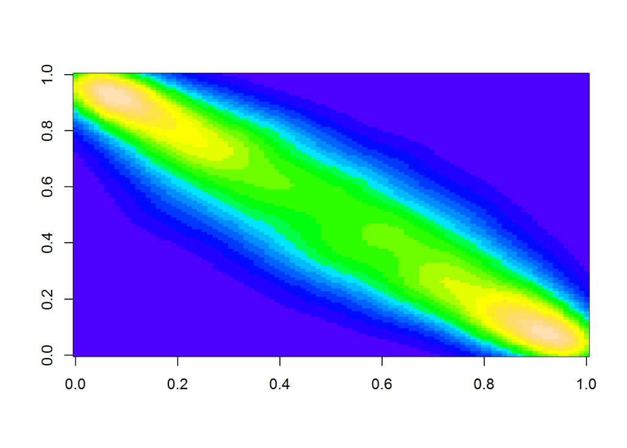

```r
par(mfrow=c(1,1))
k <- kde2d(rank(Simulated.Gaussian.Copula.Minus0.9[,1])/SimulatedN,
           rank(Simulated.Gaussian.Copula.Minus0.9[,2])/SimulatedN, n=100)
image(k,col=topo.colors(20))
```

### 2.1.3 Case: $\rho=0$

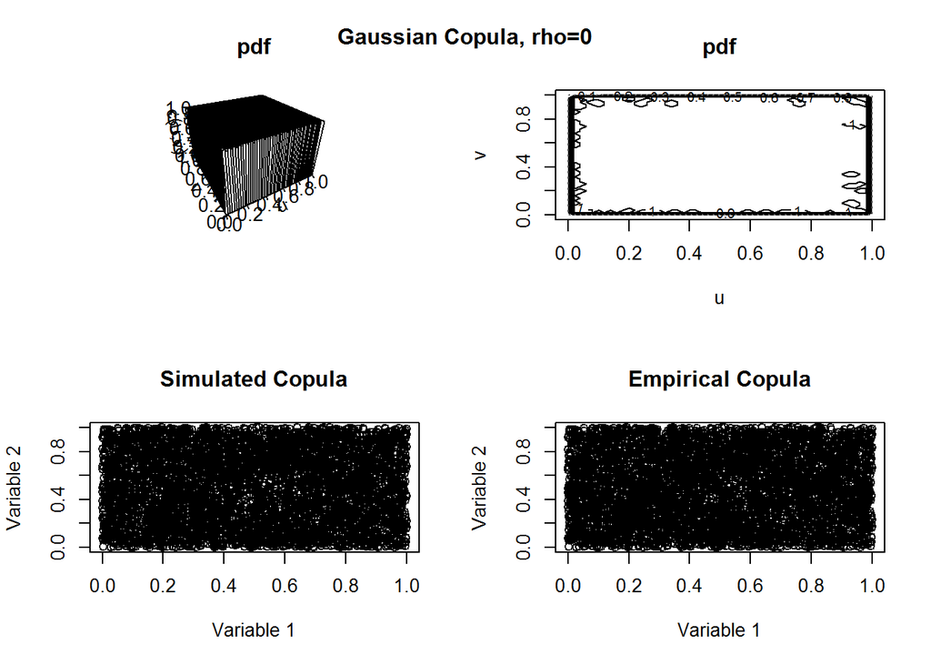

```r
par(mfrow=c(2,2))
set.seed(8301735)
#Gaussian Copula, rho=0
Gaussian.Copula.0<-normalCopula(param=0,dim=2)
persp(Gaussian.Copula.0, dCopula, main="pdf",xlab="u", ylab="v", zlab="c(u,v)")
contour(Gaussian.Copula.0,dCopula, main="pdf",xlab="u", ylab="v")
Simulated.Gaussian.Copula.0<-rCopula(5000,Gaussian.Copula.0)
SimulatedN<-length(Simulated.Gaussian.Copula.0[,1])
plot(Simulated.Gaussian.Copula.0,main="Simulated Copula",xlab="Variable 1",ylab="Variable 2")
plot(apply(Simulated.Gaussian.Copula.0,2,rank)/length(Simulated.Gaussian.Copula.0[,1]),main="Empirical Copula",xlab="Variable 1",ylab="Variable 2")
title("Gaussian Copula, rho=0",outer=TRUE,line=-2)
```

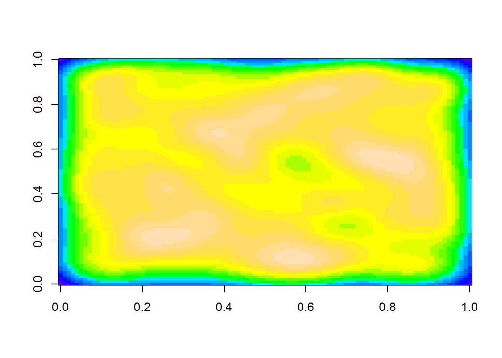

```r
par(mfrow=c(1,1))
k <- kde2d(rank(Simulated.Gaussian.Copula.0[,1])/SimulatedN,
           rank(Simulated.Gaussian.Copula.0[,2])/SimulatedN, n=100)
image(k,col=topo.colors(20))
```

# 3 Simulation of dependent random variables using copulas.

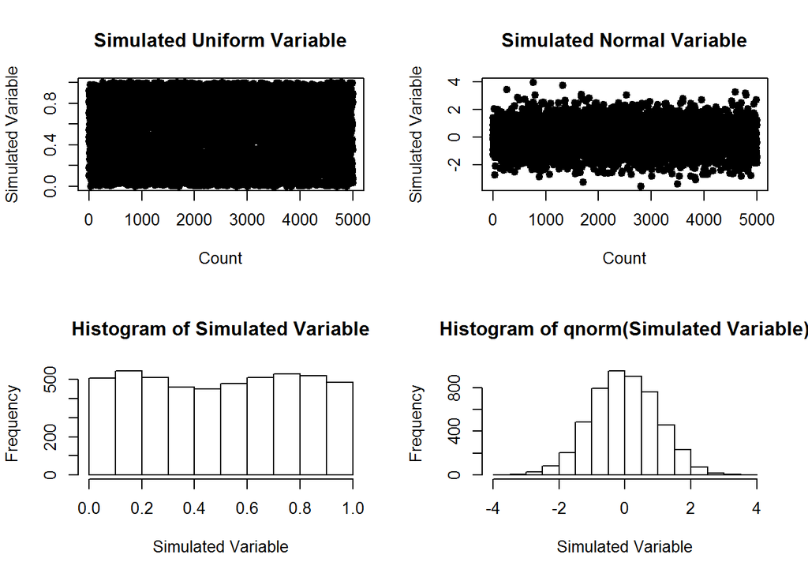

```r
par(mfrow=c(2,2))
matplot(1:5000,Simulated.Gaussian.Copula.0.9[,1],pch=19,main="Simulated Uniform Variable",xlab="Count",ylab="Simulated Variable")
matplot(1:5000,qnorm(Simulated.Gaussian.Copula.0.9[,1]),pch=19,main="Simulated Normal Variable",xlab="Count",ylab="Simulated Variable")
hist(Simulated.Gaussian.Copula.0.9[,2],main="Histogram of Simulated Variable",xlab="Simulated Variable",ylab="Frequency")
hist(qnorm(Simulated.Gaussian.Copula.0.9[,1]),main="Histogram of qnorm(Simulated Variable)",xlab="Simulated Variable",ylab="Frequency")
```

Comparison of the simulated copula with the empirical copula.

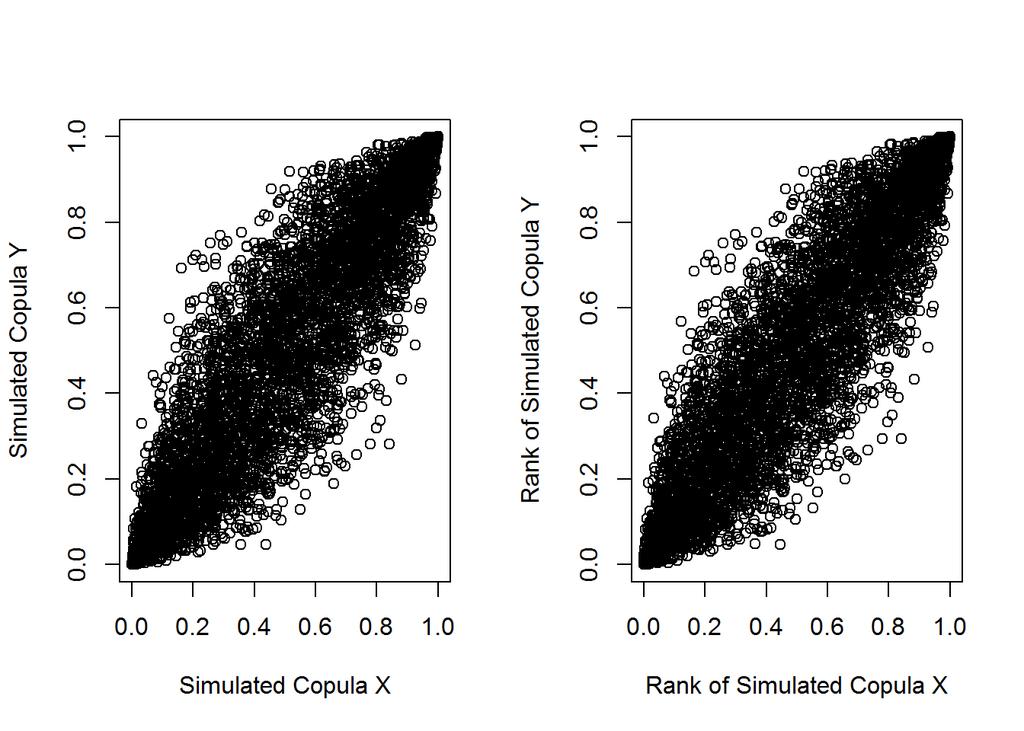

```r
par(mfrow=c(1,2))
plot(Simulated.Gaussian.Copula.0.9[,1],Simulated.Gaussian.Copula.0.9[,2],xlim=c(0,1),ylim=c(0,1),
     xlab="Simulated Copula X",ylab="Simulated Copula Y")
plot(rank(qnorm(Simulated.Gaussian.Copula.0.9[,1]))/5000,rank(qnorm(Simulated.Gaussian.Copula.0.9[,2]))/5000,
     xlim=c(0,1),ylim=c(0,1),xlab="Rank of Simulated Copula X",ylab="Rank of Simulated Copula Y")
```

One of the marginal distributions changes to exponential distribution. The scatterplot gets affected, but the copula does not.

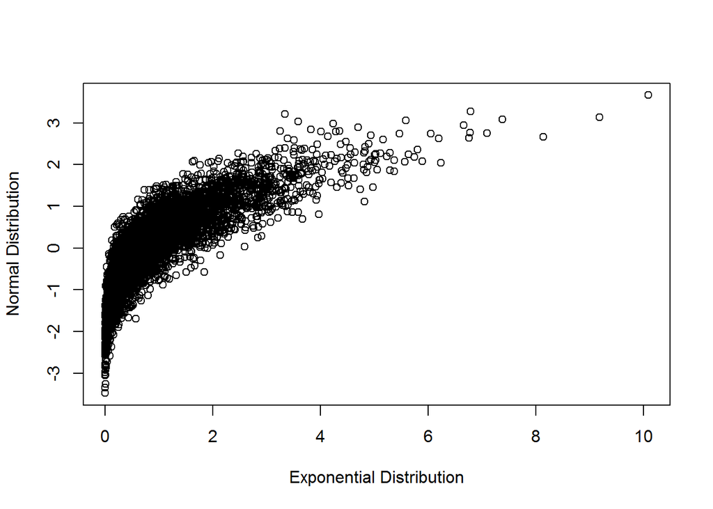

```r
plot(qexp(Simulated.Gaussian.Copula.0.9[,1],1),qnorm(Simulated.Gaussian.Copula.0.9[,2]),
     xlab="Exponential Distribution",ylab="Normal Distribution")
```

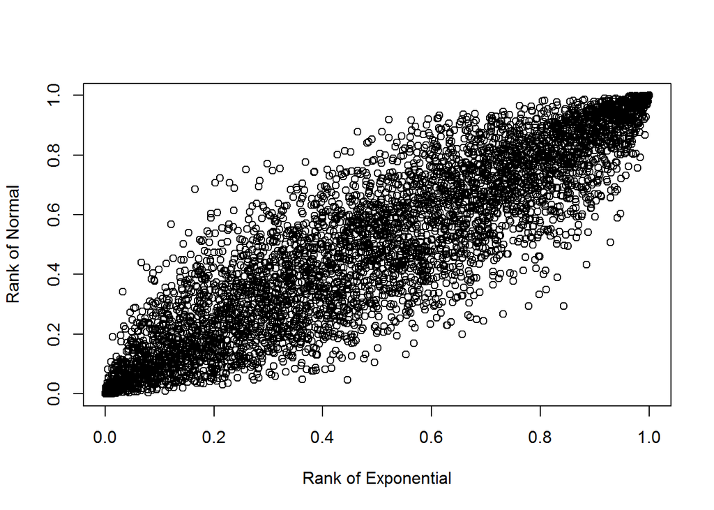

```r
plot(rank(qexp(Simulated.Gaussian.Copula.0.9[,1],1))/5000,rank(qnorm(Simulated.Gaussian.Copula.0.9[,2]))/5000,
     xlim=c(0,1),ylim=c(0,1),xlab="Rank of Exponential",ylab="Rank of Normal")
```

# 4 Types of dependency

## 4.1 Tail dependence

### 4.1.1 Upper tail dependence: Gumbel copula

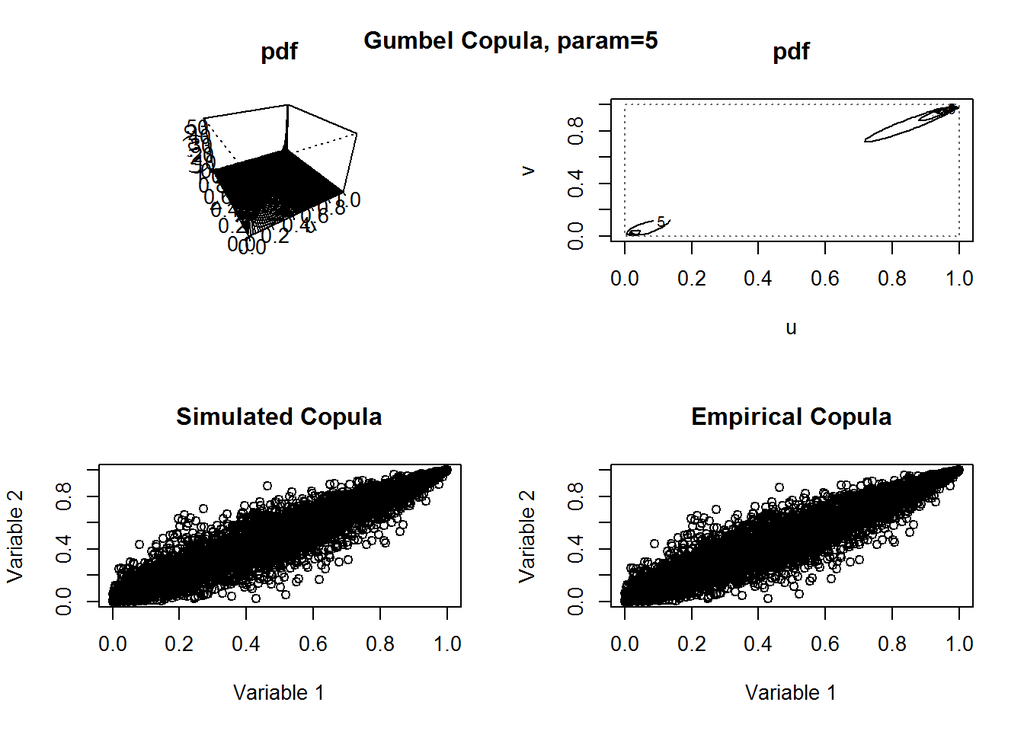

```r
par(mfrow=c(2,2))
set.seed(8301735)
#Gumbel Copula, rho=0
Gumbel.Copula.5<-gumbelCopula(param=5,dim=2)
persp(Gumbel.Copula.5, dCopula, main="pdf",xlab="u", ylab="v", zlab="c(u,v)")
contour(Gumbel.Copula.5,dCopula, main="pdf",xlab="u", ylab="v")
Simulated.Gumbel.Copula.5<-rCopula(5000,Gumbel.Copula.5)
SimulatedN<-length(Simulated.Gumbel.Copula.5[,1])
plot(Simulated.Gumbel.Copula.5,main="Simulated Copula",xlab="Variable 1",ylab="Variable 2")
plot(apply(Simulated.Gumbel.Copula.5,2,rank)/SimulatedN,main="Empirical Copula",xlab="Variable 1",ylab="Variable 2")
title("Gumbel Copula, param=5",outer=TRUE,line=-2)
```

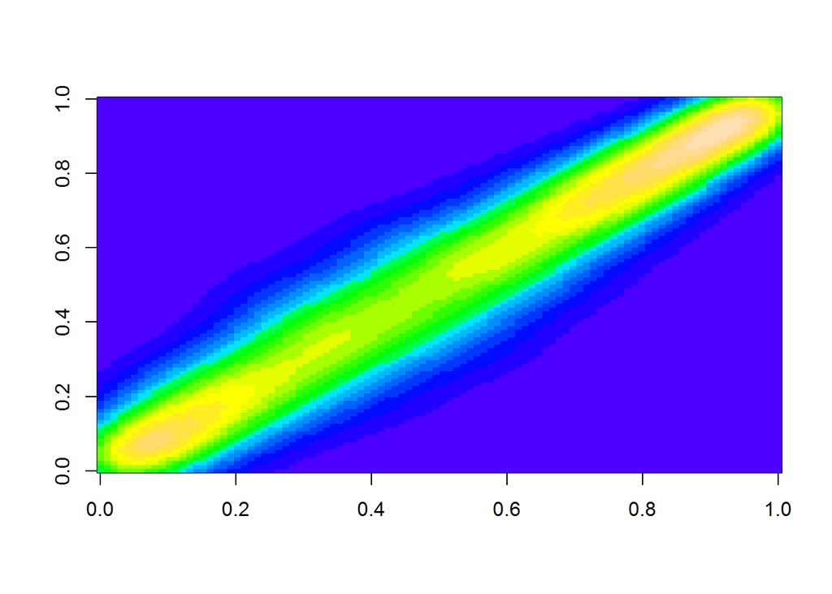

```r
par(mfrow=c(1,1))
k <- kde2d(rank(Simulated.Gumbel.Copula.5[,1])/SimulatedN,
           rank(Simulated.Gumbel.Copula.5[,2])/SimulatedN, n=100)
image(k,col=topo.colors(20))
```

### 4.1.2 Lower tail dependence: Clayton copula.

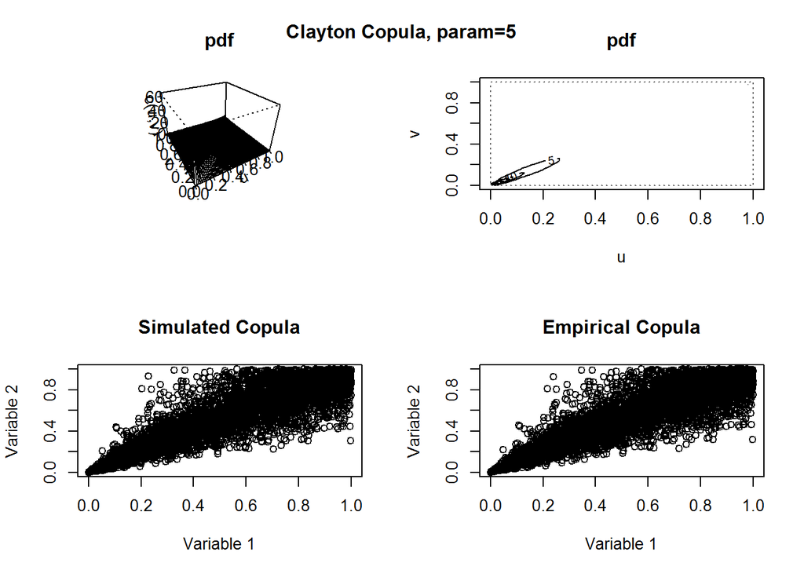

```r
par(mfrow=c(2,2))
set.seed(8301735)
#Clayton Copula, rho=0
Clayton.Copula.5<-claytonCopula(param=5,dim=2)
persp(Clayton.Copula.5, dCopula, main="pdf",xlab="u", ylab="v", zlab="c(u,v)")
contour(Clayton.Copula.5,dCopula, main="pdf",xlab="u", ylab="v")
Simulated.Clayton.Copula.5<-rCopula(5000,Clayton.Copula.5)
SimulatedN<-length(Simulated.Clayton.Copula.5[,1])
plot(Simulated.Clayton.Copula.5,main="Simulated Copula",xlab="Variable 1",ylab="Variable 2")
SimulatedN<-length(Simulated.Clayton.Copula.5[,1])
plot(apply(Simulated.Clayton.Copula.5,2,rank)/SimulatedN,main="Empirical Copula",
     xlab="Variable 1",ylab="Variable 2")
title("Clayton Copula, param=5",outer=TRUE,line=-2)
```

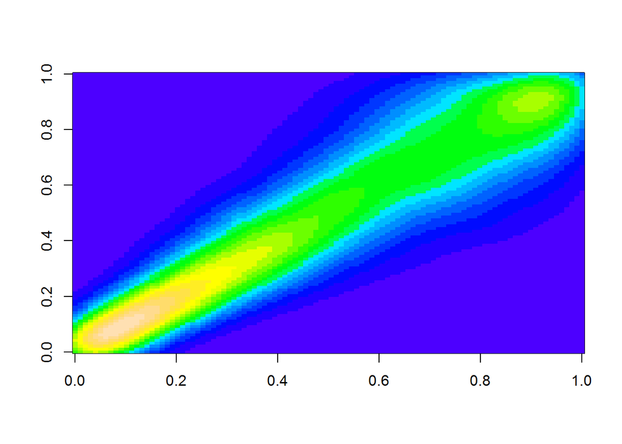

```r
par(mfrow=c(1,1))
k <- kde2d(rank(Simulated.Clayton.Copula.5[,1])/SimulatedN,
           rank(Simulated.Clayton.Copula.5[,2])/SimulatedN, n=100)
image(k,col=topo.colors(20))
```

### 4.1.3 Symmetrical tail dependence: Frank copula.

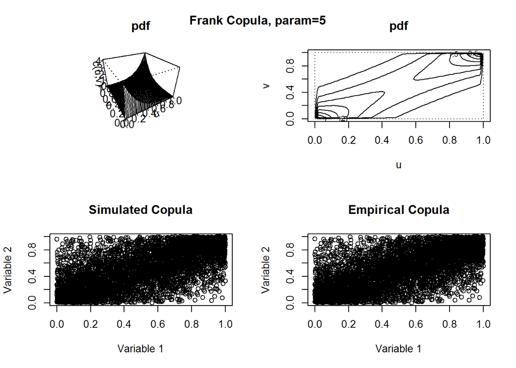

```r
#Frank copula.
par(mfrow=c(2,2))
set.seed(8301735)
#Frank Copula, Theta=5
Frank.Copula<-frankCopula(param=5,dim=2)
persp(Frank.Copula, dCopula, main="pdf",xlab="u", ylab="v", zlab="c(u,v)")
contour(Frank.Copula,dCopula, main="pdf",xlab="u", ylab="v")
Simulated.Frank.Copula<-rCopula(5000,Frank.Copula)
SimulatedN<-length(Simulated.Frank.Copula[,1])
plot(Simulated.Frank.Copula,main="Simulated Copula",xlab="Variable 1",ylab="Variable 2")
Empirical.Frank.Copula<-apply(Simulated.Frank.Copula,2,rank)/SimulatedN
plot(Empirical.Frank.Copula,main="Empirical Copula",xlab="Variable 1",ylab="Variable 2")
title("Frank Copula, param=5",outer=TRUE,line=-2)
```

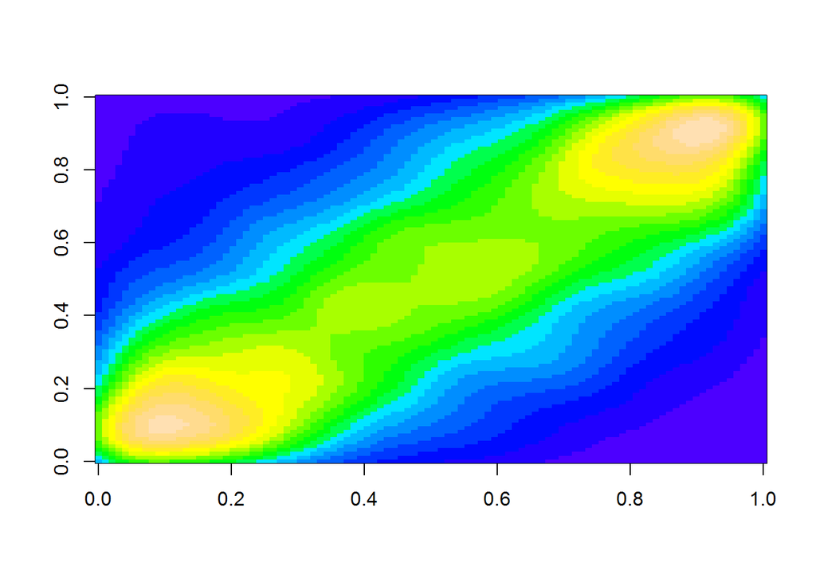

```r
par(mfrow=c(1,1))
k <- kde2d(rank(Simulated.Frank.Copula[,1])/SimulatedN,
           rank(Simulated.Frank.Copula[,2])/SimulatedN, n=100)
image(k,col=topo.colors(20))
```

# 5 Fitting a Copula

Fit Gaussian copula to `Simulated.Gaussian.Copula.0.9` with normal marginal distributions.

1. Create the sample:

```r
Sample.For.Fitting.Gaussian.Copula<-cbind(qnorm(Simulated.Gaussian.Copula.0.9[,1]),
                                          qnorm(Simulated.Gaussian.Copula.0.9[,2],3,5))
```

Check the correlation between the variables.

```r
cor(Sample.For.Fitting.Gaussian.Copula)
```

```
##           [,1]      [,2]
## [1,] 1.0000000 0.8989925
## [2,] 0.8989925 1.0000000
```

Fit Gaussian copula.

```r
Gaussian.Copula.Object<-normalCopula(param=0,dim=2)
Gaussian.Copula.fit<-fitCopula(Gaussian.Copula.Object,
          pobs(Sample.For.Fitting.Gaussian.Copula,ties.method = "average"),
          method = "ml",
          optim.method = "BFGS",
          optim.control = list(maxit=1000))
Gaussian.Copula.fit
```

```
## fitCopula() estimation based on 'maximum likelihood'
## and a sample of size 5000.
##       Estimate Std. Error z value Pr(>|z|)
## rho.1 0.899011   0.002017   445.8   <2e-16 ***
## ---
## Signif. codes:  0 '***' 0.001 '**' 0.01 '*' 0.05 '.' 0.1 ' ' 1
## The maximized loglikelihood is  4122
## Optimization converged
## Number of loglikelihood evaluations:
## function gradient
##       25        3
```

Check how `pobs()` works

```r
(pobs.manual<-head(apply(Sample.For.Fitting.Gaussian.Copula,2,function(z) rank(z)/(length(z)+1))))
```

```
##           [,1]      [,2]
## [1,] 0.9210158 0.9498100
## [2,] 0.8142372 0.5500900
## [3,] 0.8090382 0.7398520
## [4,] 0.1849630 0.2725455
## [5,] 0.5506899 0.4225155
## [6,] 0.7012597 0.7370526
```

```r
head(pobs(Sample.For.Fitting.Gaussian.Copula,ties.method = "average"))
```

```
##           [,1]      [,2]
## [1,] 0.9210158 0.9498100
## [2,] 0.8142372 0.5500900
## [3,] 0.8090382 0.7398520
## [4,] 0.1849630 0.2725455
## [5,] 0.5506899 0.4225155
## [6,] 0.7012597 0.7370526
```

Function `pobs()` creates pseudo observations from a matrix of observations by calculating empirical distributions of columns and renormalizing them.

```r
(exampleData<-cbind(1:5,10:6))
```

```
##      [,1] [,2]
## [1,]    1   10
## [2,]    2    9
## [3,]    3    8
## [4,]    4    7
## [5,]    5    6
```

```r
pobs(exampleData)
```

```
##           [,1]      [,2]
## [1,] 0.1666667 0.8333333
## [2,] 0.3333333 0.6666667
## [3,] 0.5000000 0.5000000
## [4,] 0.6666667 0.3333333
## [5,] 0.8333333 0.1666667
```

```r
apply(exampleData,2,rank)/(dim(exampleData)[1]+1)
```

```
##           [,1]      [,2]
## [1,] 0.1666667 0.8333333
## [2,] 0.3333333 0.6666667
## [3,] 0.5000000 0.5000000
## [4,] 0.6666667 0.3333333
## [5,] 0.8333333 0.1666667
```

Alternatively, apply `hist()` to the first column of `exampleData`

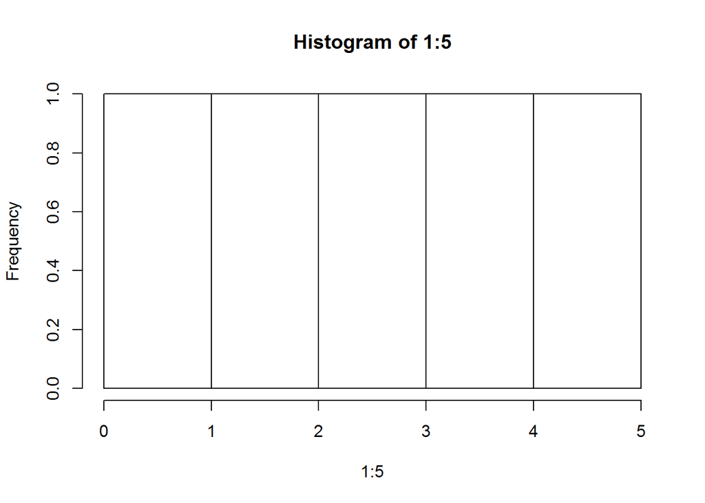

```r
h<-hist(1:5,breaks=0:5)
```

```r
cumsum(h$density)
```

```
## [1] 0.2 0.4 0.6 0.8 1.0
```

and renormalize cumulative sum of density

```r
cumsum(h$density)*5/6
```

```
## [1] 0.1666667 0.3333333 0.5000000 0.6666667 0.8333333
```

The reason for renormalization is to force all values strictly inside interval [0,1] and avoid calculation of distribution at boundaries. For large samples this renormalization does not change empirical distribution significantly.

Compare the correlations

```r
Gaussian.Copula.fit
```

```
## fitCopula() estimation based on 'maximum likelihood'
## and a sample of size 5000.
##       Estimate Std. Error z value Pr(>|z|)
## rho.1 0.899011   0.002017   445.8   <2e-16 ***
## ---
## Signif. codes:  0 '***' 0.001 '**' 0.01 '*' 0.05 '.' 0.1 ' ' 1
## The maximized loglikelihood is  4122
## Optimization converged
## Number of loglikelihood evaluations:
## function gradient
##       25        3
```

```r
cor(Sample.For.Fitting.Gaussian.Copula)
```

```
##           [,1]      [,2]
## [1,] 1.0000000 0.8989925
## [2,] 0.8989925 1.0000000
```

# 6 Workshop Project

Download example data `MScA_31010_W3CorrelationExample.csv` with two variables

```r
exampleData<-read.csv(file=paste(datapath,"MScA_31010_W3CorrelationExample.csv",sep="/"))
head(exampleData)
```

```
##            X        Y
## 1  0.3325173 5.166315
## 2  1.7115968 1.191828
## 3  0.8354408 2.586894
## 4 -0.9089969 2.861661
## 5  0.5840969 1.788850
## 6  0.1140567 3.544711
```

## 6.1 Visualize data

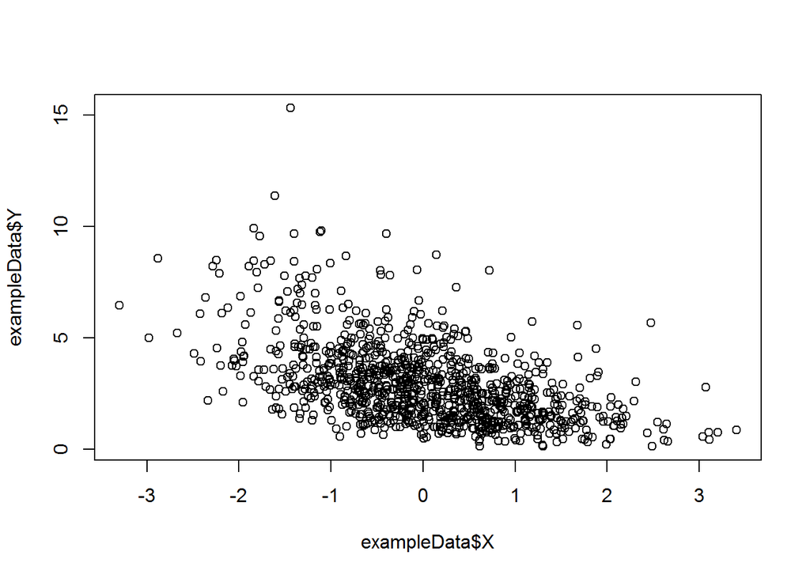

```r
plot(exampleData$X,exampleData$Y)
```

## 6.2 Find appropriate marginal distributions for variables `X` and `Y`

Use `fitdistr()` from `MASS` to find parameters of each distribution. Use Kolmogorov-Smirnov test to check if the distributions fit well.  
For the first variable `X` the analysis is:

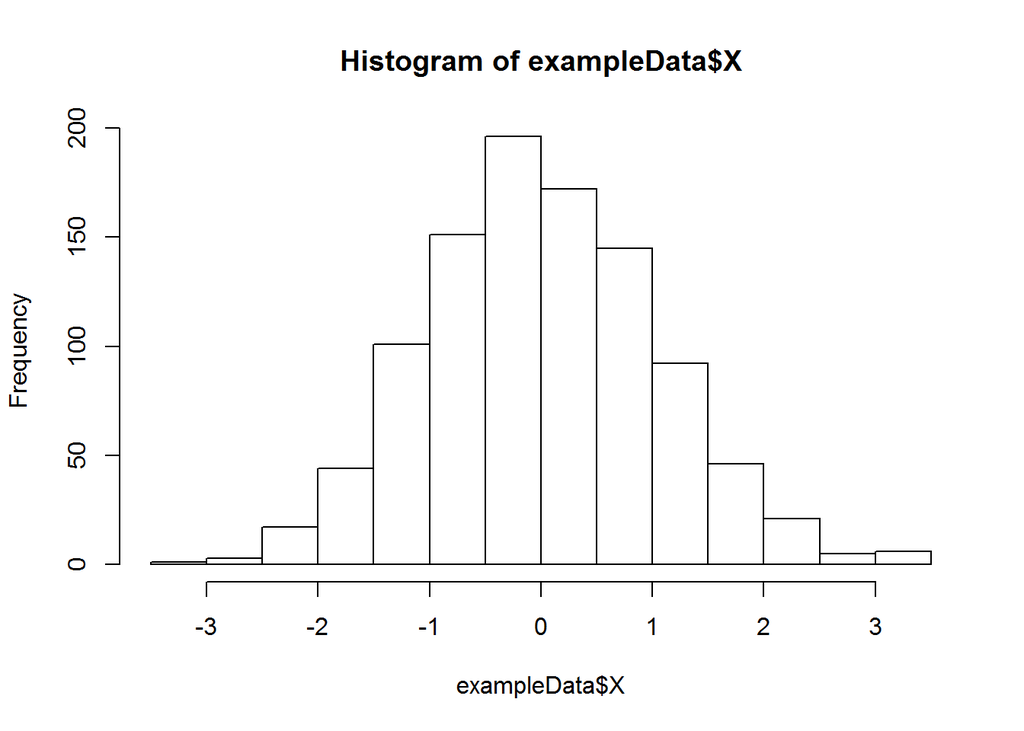

```r
hist(exampleData$X)
```

```r
(fittedDistrX<-fitdistr(exampleData$X,"normal"))
```

```
##       mean           sd
##   0.006463077   1.031432598
##  (0.032616763) (0.023063534)
```

```r
ks.test(exampleData$X,"pnorm",mean=fittedDistrX$estimate[1],sd=fittedDistrX$estimate[2])
```

```
##
##  One-sample Kolmogorov-Smirnov test
##
## data:  exampleData$X
## D = 0.022543, p-value = 0.6897
## alternative hypothesis: two-sided
```

- The histogram graph looks like normal distribution
- Function `fitdistr()` estimates parameters as

```r
fittedDistrX
```

```
##       mean           sd
##   0.006463077   1.031432598
##  (0.032616763) (0.023063534)
```

Analyze marginal distribution for `Y` yourself.  
Select from the following list of distributions: uniform, normal, lognormal, gamma, exponential.  
Check your intuition with the linked gallery of distributions.

(Skipped Code)

Report the distribution that you selected.

## 6.3 Analyze correlation of the pair `X` and `Y`

Check if you can describe the relationship with linear model,

(Skipped Code)

## 6.4 Analyze non-linear dependence between `X` and `Y`

Plot empirical copula.  
Identify one of the copulas that we studied and fit it to the data.  
Report the type of selected copula and the estimated dependence parameter.

(Skipped Code)